# FBI Data

# Combine 2015 Data with 1985-2014 Data

The 2015 data is appended to the 1985-2014 data frame for each table. The 2015 data is then removed from the environment.

```r
stLouis <- bind_rows(stLouis, stLouis15)
rm(stLouis15)
cincinnati <- bind_rows(cincinnati, cincinnati15)
rm(cincinnati15)
# newark <- bind_rows(newark, newark15)
# rm(newark15)
baltimore <- bind_rows(baltimore, baltimore15)
rm(baltimore15)
detroit <- bind_rows(detroit, detroit15)
rm(detroit15)
```

# Calculate Crime Rates and Add City Variable

For each city, an ID variable is created with a three letter abbreviation. Crime rates per 100,000 are calculated for both murders and violent crimes.

```r
stLouis <- stLouis %>%
  mutate(city = "STL") %>%
  mutate(violentRate = (violentTotal/Population)*100000) %>%
  mutate(murderRate = (murder/Population)*100000)
cincinnati <- cincinnati %>%
  mutate(city = "CVG") %>%
  mutate(violentRate = (violentTotal/Population)*100000) %>%
  mutate(murderRate = (murder/Population)*100000)
newark <- newark %>%
  mutate(city = "EWR") %>%
  mutate(violentRate = (violentTotal/Population)*100000) %>%
  mutate(murderRate = (murder/Population)*100000)
baltimore <- baltimore %>%
  mutate(city = "BAL") %>%
  mutate(violentRate = (violentTotal/Population)*100000) %>%
  mutate(murderRate = (murder/Population)*100000)
detroit <- detroit %>%
  mutate(city = "DTW") %>%
  mutate(violentRate = (violentTotal/Population)*100000) %>%
  mutate(murderRate = (murder/Population)*100000)
```

# Combine Datasets

Each city’s data is appended together into a single data frame. The individual data frames are then removed from the environment.

```r
cityMurder <- bind_rows(stLouis, newark)
rm(stLouis)
rm(newark)
cityMurder <- bind_rows(cityMurder, cincinnati)
rm(cincinnati)
cityMurder <- bind_rows(cityMurder, baltimore)
rm(baltimore)
cityMurder <- bind_rows(cityMurder, detroit)
rm(detroit)
```

# Murder Rate Plots

St. Louis, Baltimore, and Detroit:

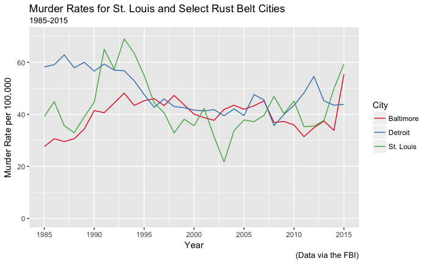

```r
murderPlot <- cityMurder %>%
  filter(city == "BAL" | city == "DTW" | city == "STL") %>%
  ggplot(aes(x = Year, y = murderRate, group = city)) +
    geom_line(aes(colour = city)) +
    scale_y_continuous(limits = c(0, 70)) +
    scale_x_continuous(breaks = c(1985, 1990, 1995, 2000, 2005, 2010, 2015)) +
    scale_colour_brewer(palette="Set1",
                      labels = c("Baltimore", "Detroit", "St. Louis"),
                      guide = guide_legend(title = "City")) +
    labs(title = "Murder Rates for St. Louis and Select Rust Belt Cities",
         subtitle = "1985-2015",
         y = "Murder Rate per 100,000",
         caption = "(Data via the FBI)")
ggsave("murderPlot.png", width = 6.5, height = 4.75, units = "in")
murderPlot
```

St. Louis, Cinncinati, and Newark:

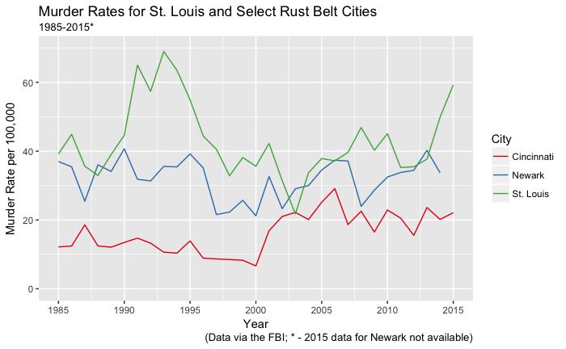

```r
murderPlot2 <- cityMurder %>%
  filter(city == "CVG" | city == "EWR" | city == "STL") %>%
  ggplot(aes(x = Year, y = murderRate, group = city)) +
    geom_line(aes(colour = city)) +
    scale_y_continuous(limits = c(0, 70)) +
    scale_x_continuous(breaks = c(1985, 1990, 1995, 2000, 2005, 2010, 2015)) +
    scale_colour_brewer(palette="Set1",
                      labels = c("Cincinnati", "Newark", "St. Louis"),
                      guide = guide_legend(title = "City")) +
    labs(title = "Murder Rates for St. Louis and Select Rust Belt Cities",
         subtitle = "1985-2015*",
         y = "Murder Rate per 100,000",
         caption = "(Data via the FBI; * - 2015 data for Newark not available)")
ggsave("murderPlot2.png", width = 6.5, height = 4.75, units = "in")
murderPlot2
```

# Violent Crime Rate Plots

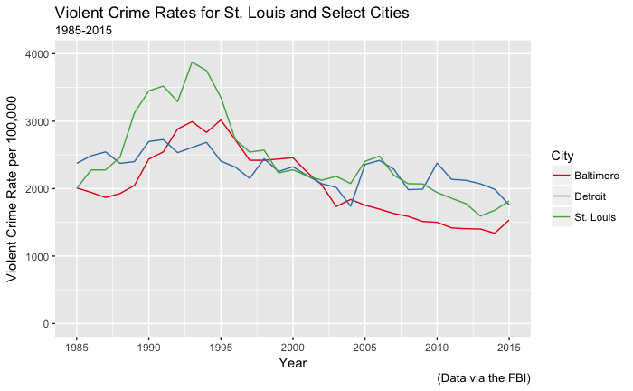

```r
violentPlot <- cityMurder %>%
  filter(!is.na(violentRate)) %>%
  filter(city == "BAL" | city == "DTW" | city == "STL") %>%
  ggplot(aes(x = Year, y = violentRate, group = city)) +
    geom_line(aes(colour = city)) +
    scale_y_continuous(limits = c(0, 4000)) +
    scale_x_continuous(breaks = c(1985, 1990, 1995, 2000, 2005, 2010, 2015)) +
    scale_colour_brewer(palette="Set1",
                      labels = c("Baltimore", "Detroit", "St. Louis"),
                      guide = guide_legend(title = "City")) +
    labs(title = "Violent Crime Rates for St. Louis and Select Cities",
         subtitle = "1985-2015",
         y = "Violent Crime Rate per 100,000",
         caption = "(Data via the FBI)")
ggsave("violentPlot.png", width = 6.5, height = 4.75, units = "in")
violentPlot
```

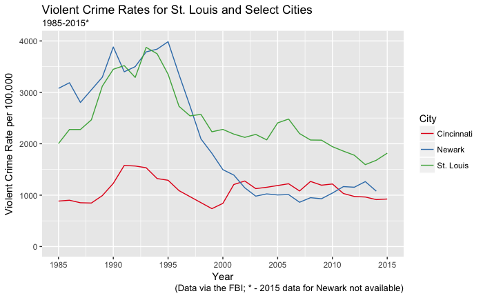

```r
violentPlot2 <- cityMurder %>%
  filter(!is.na(violentRate)) %>%
  filter(city == "CVG" | city == "EWR" | city == "STL") %>%
  ggplot(aes(x = Year, y = violentRate, group = city)) +
    geom_line(aes(colour = city)) +
    scale_y_continuous(limits = c(0, 4000)) +
    scale_x_continuous(breaks = c(1985, 1990, 1995, 2000, 2005, 2010, 2015)) +
    scale_colour_brewer(palette="Set1",
                      labels = c("Cincinnati", "Newark", "St. Louis"),
                      guide = guide_legend(title = "City")) +
    labs(title = "Violent Crime Rates for St. Louis and Select Cities",
         subtitle = "1985-2015*",
         y = "Violent Crime Rate per 100,000",
         caption = "(Data via the FBI; * - 2015 data for Newark not available)")
ggsave("violentPlot2.png", width = 6.5, height = 4.75, units = "in")
violentPlot2
```

# Analysis

St. Louis does not compare well to current trends with similarly sized rust belt cities (Newark and Cincinnati). Though Newark’s crime rate during the late 1980s and the 1990s was comparable, it has dropped off substantially from the pace St. Louis has remained on throughout the 2000s.

Both Detroit and Baltimore - cities with twice the population of St. Louis - are better reference groups for crime rates. Both cities have comparable trends in violent crime rates, with Baltimore having a similarly timed recent upswing in violent crime. Though the variance in murders for St. Louis is much larger than for Baltimore or Detroit, the patters are relatively simiarl. Like violent crime, Baltimore has a similarly timed recent upswing in murders.